# Finding Similar Board Games

Phil Henrickson

2021-12-12

## What is this analysis?

This notebook is for selecting any boardgame and identifying **its most comparable games using data from boardgamegeek.com**. I use a dimension reduction method (PCA) to learn the main points of variation in data about games from boardgamegee - this gives me a vector with every game’s value on each of the principal components. To find similar games, I compute the distance between all games using the first ten principal components. I use the distance between games to determine their overall similarity. Games that are close to each other are said to be *neighbors*.

This document details a game’s 25 nearest neighbors and illustrate some of the dimensions that make the selected game and its neighbors similar.

## Game Profile: **Khôra: Rise of an Empire**

Summary information for the selected game.

| ID | Game | Published | Player Count | Playing Time | UserRatings | Average | GeekRating | Complexity |
| --- | --- | --- | --- | --- | --- | --- | --- | --- |
| 299684 | Khôra: Rise of an Empire | 2021 | 2-4 | 75 min | 728 | 7.61 | 6.1 | 2.79 |

Information on the game’s designers, artists, mechanics and categories. Note: designer and artist features are not used in identifying nearest neighbors.

| Publisher(s) | Designer(s) | Artist(s) | Categories | Mechanics |
| --- | --- | --- | --- | --- |
| Portal Games | Head Quarter Simulation Game Club | David Chapoulet | Economic | Simultaneous Action Selection |
| White Goblin Games |  | Jocelyn Joc Millet | City Building | Card Drafting |
| Korea Boardgames Co Ltd |  |  | Ancient | Dice Rolling |
| Iello |  |  |  | Race |
| Hutter Trade Gmbh Co Kg |  |  |  | Income |
| Mancalamaro |  |  |  | Investment |

For the full profile of the selected game, go to https://boardgamegeek.com/boardgame/299684

## Most Similar Games to **Khôra: Rise of an Empire**

The table below displays the most similar games to Khôra: Rise of an Empire using data from boardgamegeek (BGG). The reported similarity score is the (squared) inverse of the Manhattan distance between two games.

**Note:** The analysis does not make use of a game’s number of ratings, average, or geek average, but instead looks only at a game’s categories, mechanics, playing time, player count, and complexity. The current approach for computing the distance weighs each component equally; I plan to explore a change to this in the future by using different measures of distance, as we would reasonably expect some components to be more important than others. I initially relied on Euclidean distance, but in tinkering with the results I have opted to go with the Manhattan distance for now.

| Rank | Similarity | Published | ID | Neighbor | BGGRating | GeekRating | Complexity |
| --- | --- | --- | --- | --- | --- | --- | --- |
| 1 | 31.24 | 2002 | 3076 | Puerto Rico | 7.97 | 7.84 | 3.28 |
| 2 | 31.05 | 2017 | 199383 | Calimala | 7.20 | 6.39 | 2.81 |
| 3 | 30.70 | 2018 | 245638 | Coimbra | 7.67 | 7.33 | 3.28 |
| 4 | 30.43 | 2019 | 284818 | Caylus 1303 | 7.59 | 6.56 | 2.93 |
| 5 | 30.14 | 2021 | 289550 | Lions of Lydia | 7.17 | 5.79 | 1.91 |
| 6 | 29.89 | 2020 | 311193 | Anno 1800 | 7.88 | 6.82 | 3.15 |
| 7 | 29.52 | 2005 | 18602 | Caylus | 7.75 | 7.58 | 3.80 |
| 8 | 29.00 | 2019 | 280480 | Crystal Palace | 7.61 | 6.72 | 3.80 |
| 9 | 28.81 | 2019 | 287941 | Formosa Tea | 7.57 | 5.89 | 3.32 |
| 10 | 28.63 | 2013 | 139898 | Brew Crafters | 7.43 | 6.71 | 3.58 |
| 11 | 28.52 | 1996 | 270 | Svea Rike | 6.40 | 5.70 | 2.47 |
| 12 | 28.44 | 1995 | 46 | Medici | 7.16 | 6.84 | 2.26 |
| 13 | 28.25 | 2019 | 275010 | De Vulgari Eloquentia: Deluxe Edition | 7.97 | 5.89 | 3.52 |
| 14 | 28.21 | 2005 | 19857 | Glory to Rome | 7.49 | 7.25 | 2.93 |
| 15 | 28.21 | 2015 | 169794 | Haspelknecht | 7.25 | 6.39 | 3.04 |
| 16 | 27.89 | 2018 | 229853 | Teotihuacan: City of Gods | 7.93 | 7.64 | 3.76 |
| 17 | 27.87 | 2008 | 34599 | Toledo | 6.25 | 5.91 | 2.18 |
| 18 | 27.78 | 2011 | 104006 | Village | 7.52 | 7.34 | 3.07 |
| 19 | 27.72 | 2017 | 227789 | Heaven & Ale | 7.57 | 7.15 | 3.24 |
| 20 | 27.66 | 2014 | 125050 | Pay Dirt | 6.74 | 5.86 | 2.57 |
| 21 | 27.21 | 2021 | 317457 | Dinosaur World | 7.66 | 6.15 | 3.31 |
| 22 | 27.17 | 2018 | 252446 | Key Flow | 7.41 | 6.28 | 2.86 |
| 23 | 27.14 | 2017 | 221194 | Dinosaur Island | 7.69 | 7.38 | 3.03 |
| 24 | 27.14 | 2010 | 66362 | Glen More | 7.31 | 7.02 | 2.68 |
| 25 | 27.12 | 2013 | 145203 | Prosperity | 6.68 | 6.10 | 2.56 |

## Plotting Comparable Games to **Khôra: Rise of an Empire**

Placing the selected game and its nearest neighbors on the first two principal components.

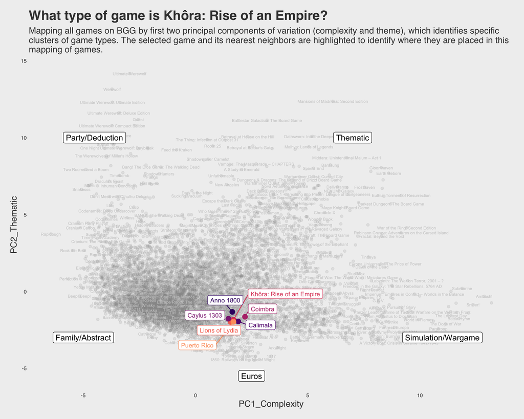

Placing games on the first four principal components, which I have found to loosely map to complexity, theme, economy, and cooperation.

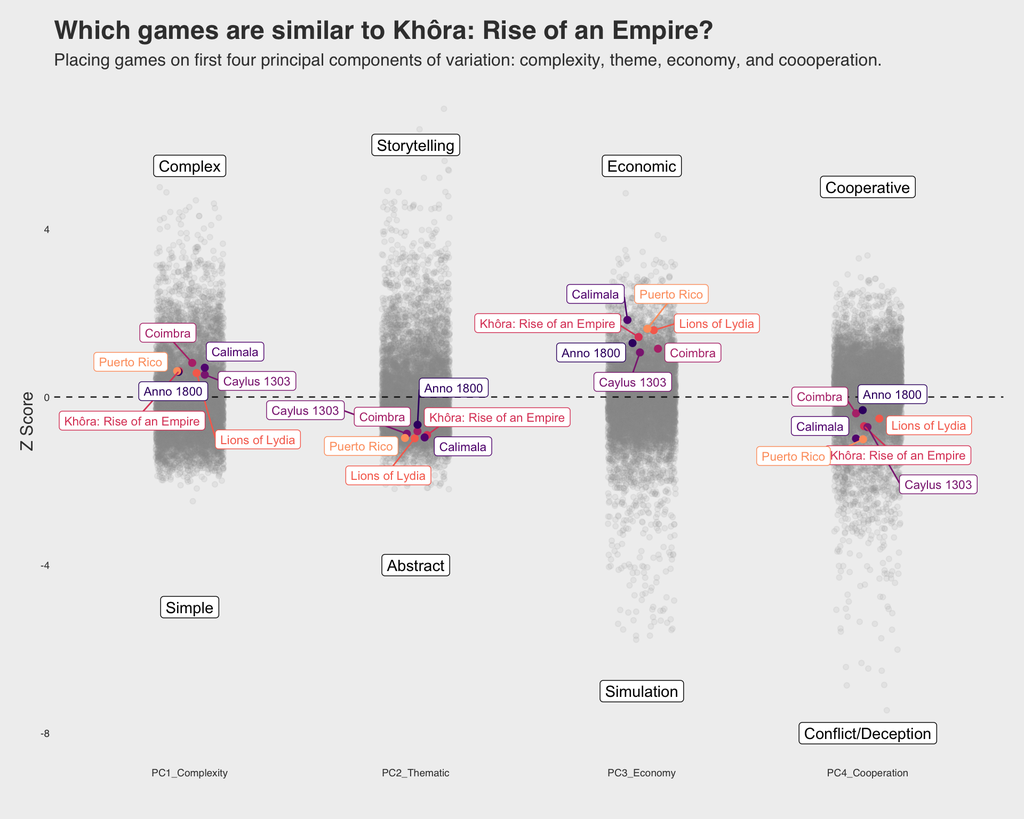